# Assignment3

### Basic Plotting in R

Task 1 a) # One Dimensional Plotting First we look at the possibilities to plot in R with one dimension:

Histogram 1D, many observations, ordered, distribution

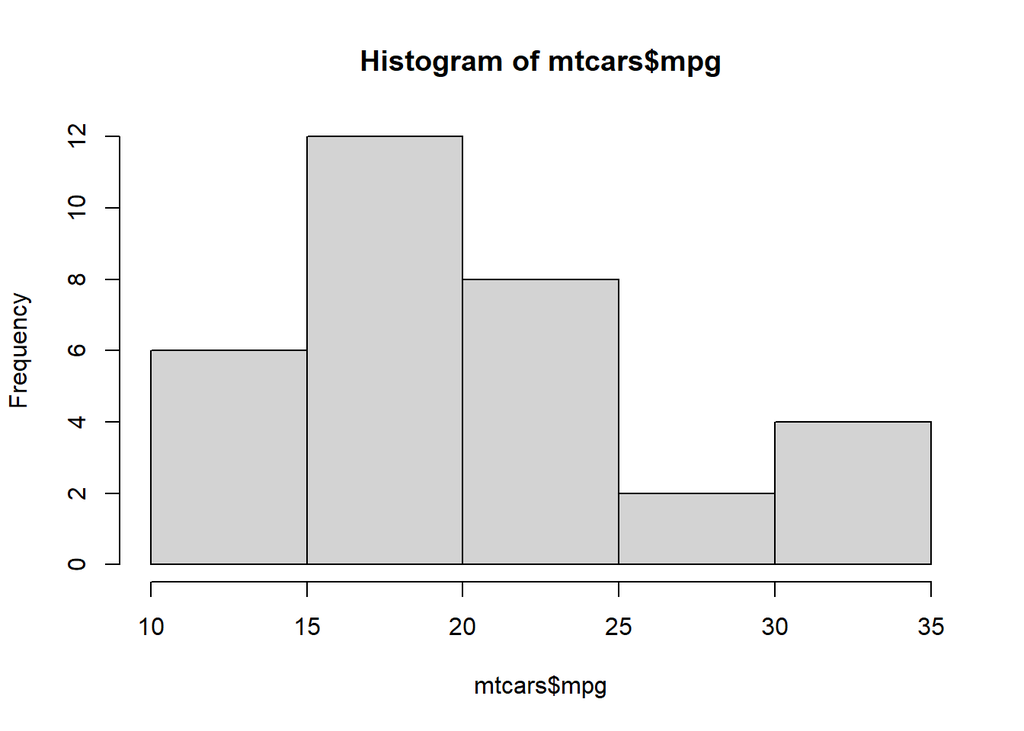

```r
# here we plot the fuel efficiency in miles per gallon for each of the 32 cars in the dataset.

hist(mtcars$mpg)# mtcarsmpg is a build in dataset
```

```r
stem(mtcars$mpg)
```

```
##
##   The decimal point is at the |
##
##   10 | 44
##   12 | 3
##   14 | 3702258
##   16 | 438
##   18 | 17227
##   20 | 00445
##   22 | 88
##   24 | 4
##   26 | 03
##   28 |
##   30 | 44
##   32 | 49
```

Boxplot 1D, continuous, many observations, orderd by quantile

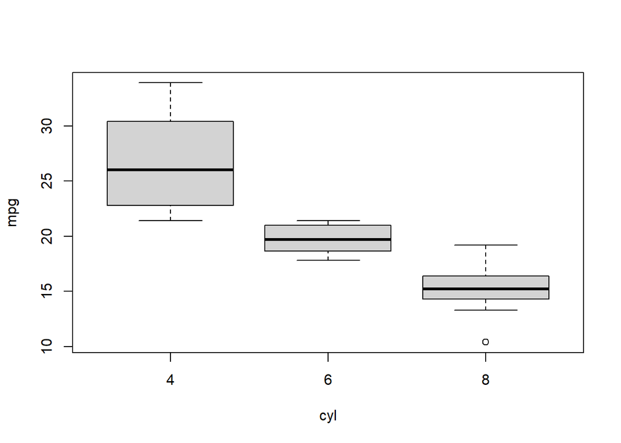

```r
boxplot(mpg ~ cyl, data = mtcars)#Plots one boxplot of mpg for each cylinder group (4, 6, 8), showing median, quartiles, and outliers of fuel efficiency per engine size.
```

Dot plot 1D, continuous, distribution

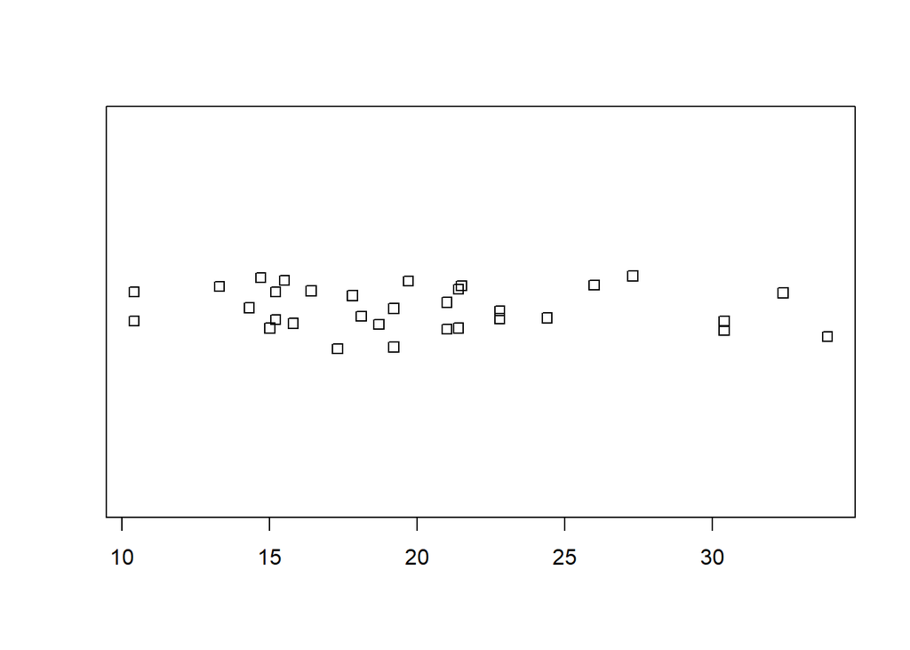

```r
stripchart(mtcars$mpg, method = "jitter")#Plots each car's mpg value as a single point along one axis, with jitter added so overlapping points are visible.
```

Barplot 1D, comparison/composition

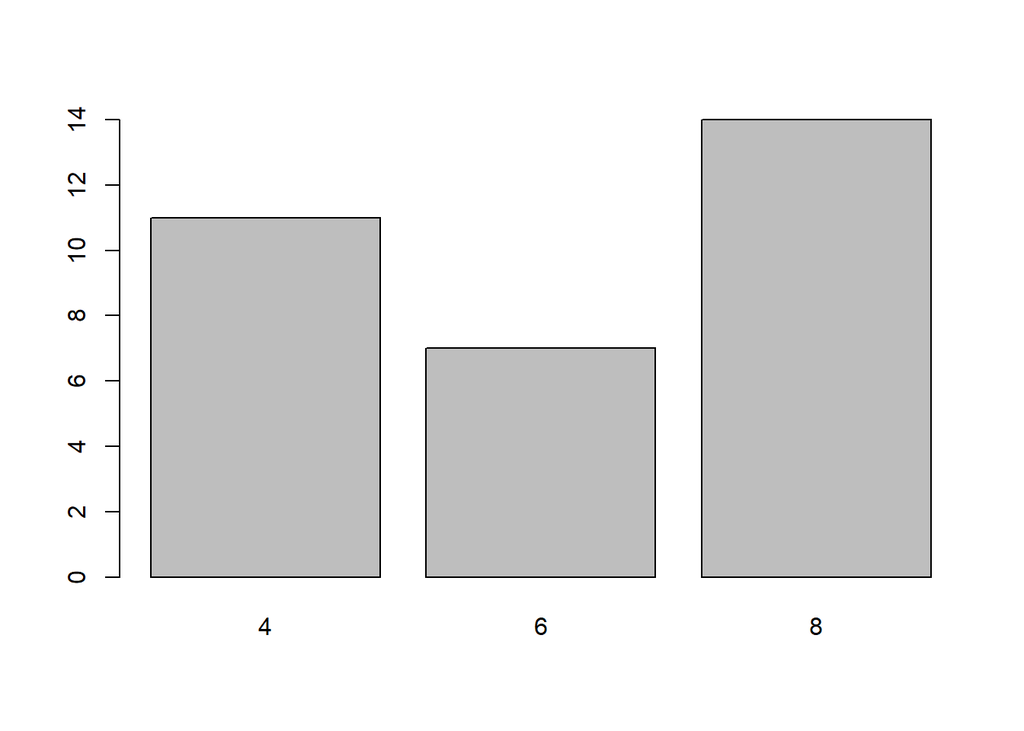

```r
barplot(table(mtcars$cyl))#Plots the count of cars for each cylinder category (4, 6, 8) as bars.
```

Pie Chart 1D, categorical, few observations, unordered, compositions

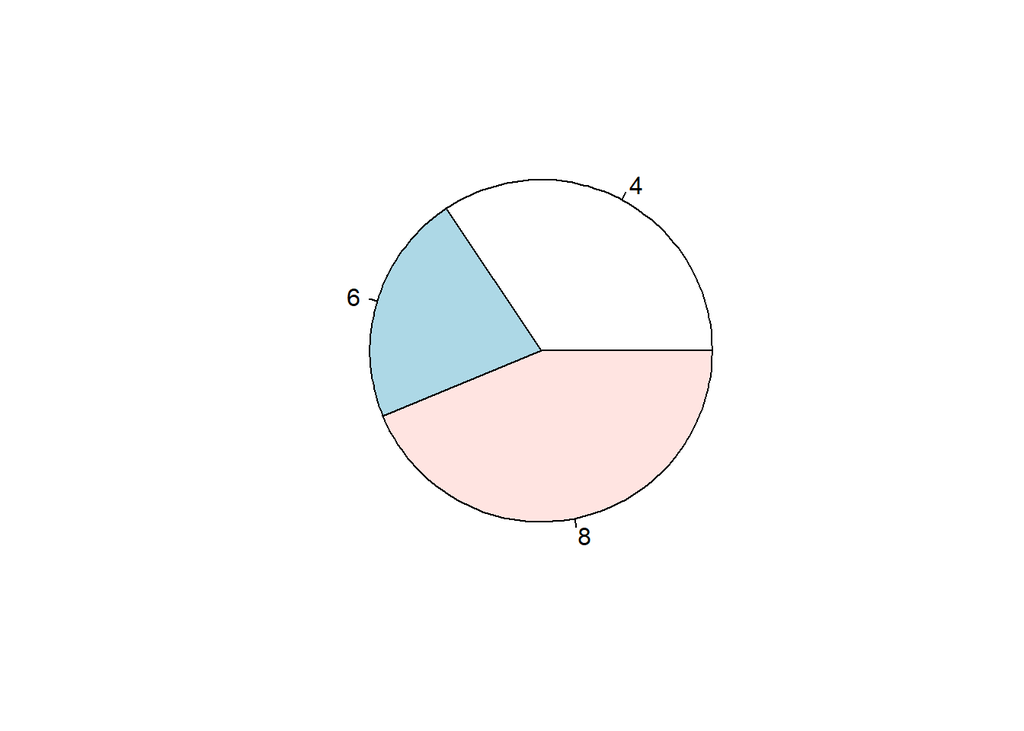

```r
pie(table(mtcars$cyl))#Plots the share of cars in each cylinder category (4, 6, 8) as slices of a circle.
```

# Two Dimensional plotting

generic scatter plot 2D, continuous, few-many-observations

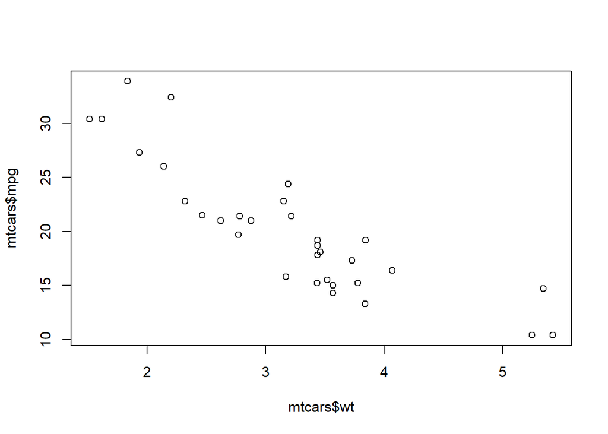

```r
plot(mtcars$wt, mtcars$mpg)#Plots each car as a point with weight on the x-axis and mpg on the y-axis to reveal how fuel efficiency relates to vehicle weight.
```

density shaded scatter 2D, continuous, many observations, unordered, distribution/relationship

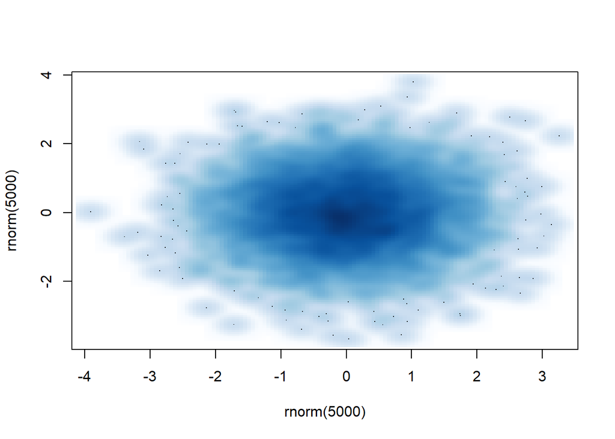

```r
smoothScatter(rnorm(5000), rnorm(5000))#Plots 5000 randomly generated (x, y) points from a normal distribution as a smoothed color density, with darker areas indicating where many points overlap.
```

Scatter with overlap markers

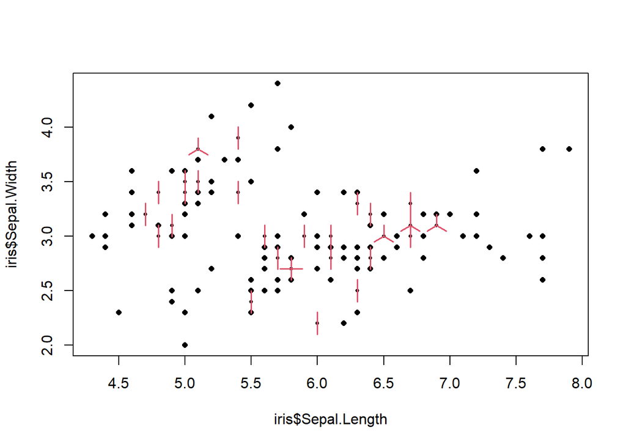

```r
sunflowerplot(iris$Sepal.Length, iris$Sepal.Width)#Plots iris flowers as points with sepal length vs. sepal width, drawing "petals" on any point that represents multiple identical observations
```

quantile quantile plots 2D, continuous, many observations

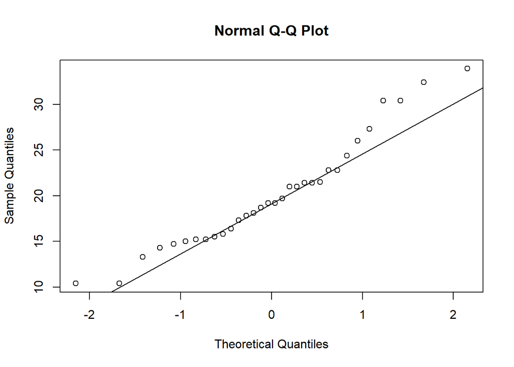

```r
qqnorm(mtcars$mpg); qqline(mtcars$mpg)#Plots the quantiles of mpg against the theoretical quantiles of a normal distribution; the closer the points hug the reference line, the more normally distributed mpg is.
```

Multiple series on shared axes 2D, continuous, many observations, ordered

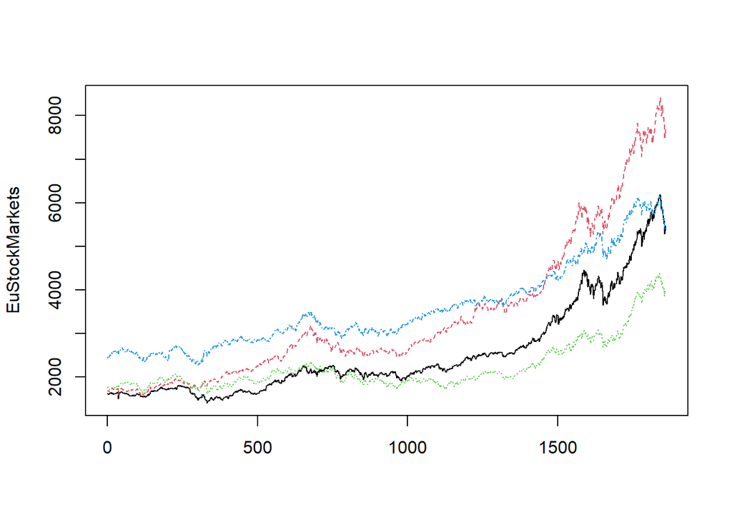

```r
matplot(EuStockMarkets, type = "l")#Plots the daily closing prices of four European stock indices (DAX, SMI, CAC, FTSE) as four lines on the same chart over time.
```

spine plot 2D, categorical, ordered

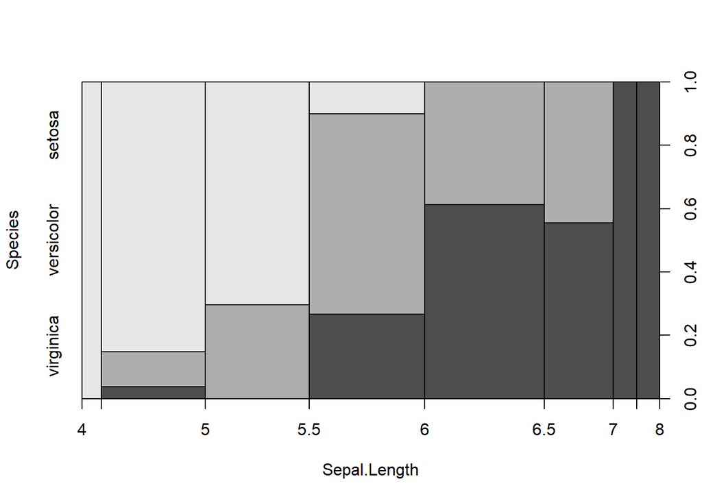

```r
spineplot(Species ~ Sepal.Length, data = iris)#Plots how the proportions of the three iris species change across bins of sepal length, with bar widths scaled to bin frequency.
```

conditional density plot

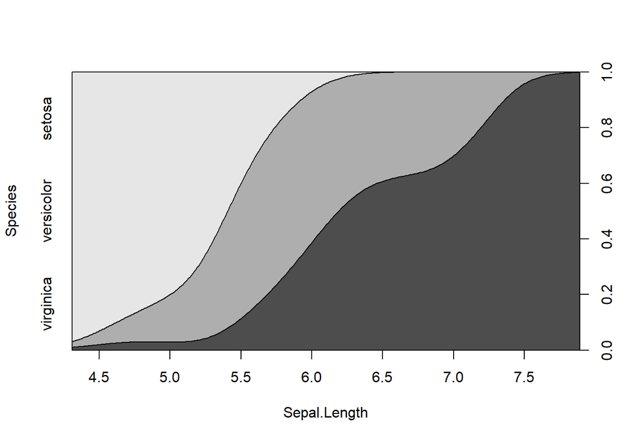

```r
cdplot(Species ~ Sepal.Length, data = iris)#Plots a smoothed estimate of how the conditional probability of each iris species changes as sepal length increases
```

# Plotting in 3D

heatmap of a matrix 2D representation of 3D, continuous, many observations, ordered grid

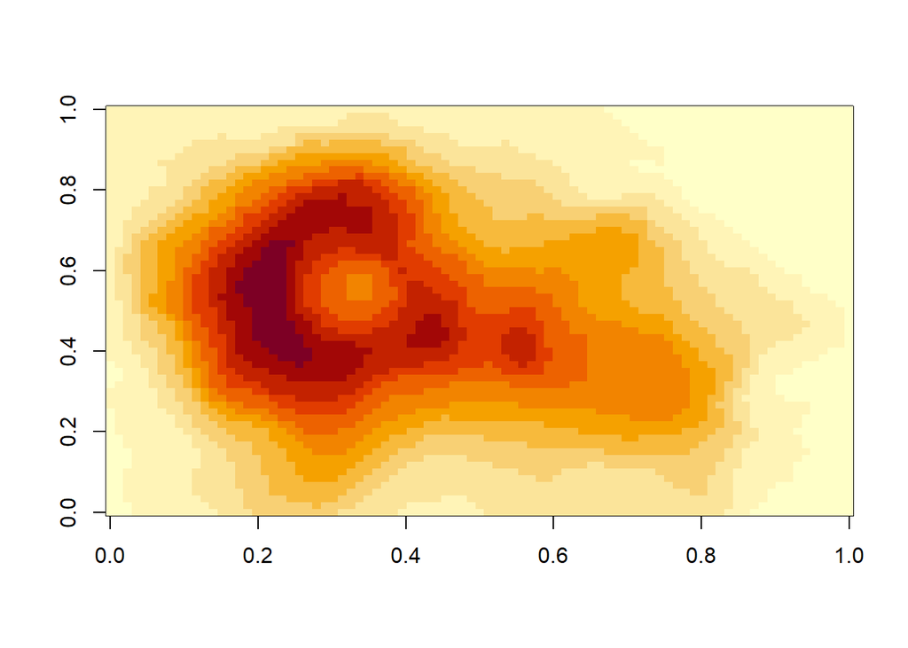

```r
image(volcano)#Plots elevation values from the volcano dataset (Maunga Whau in Auckland) as a color-coded grid, where color indicates height.
```

contour lines

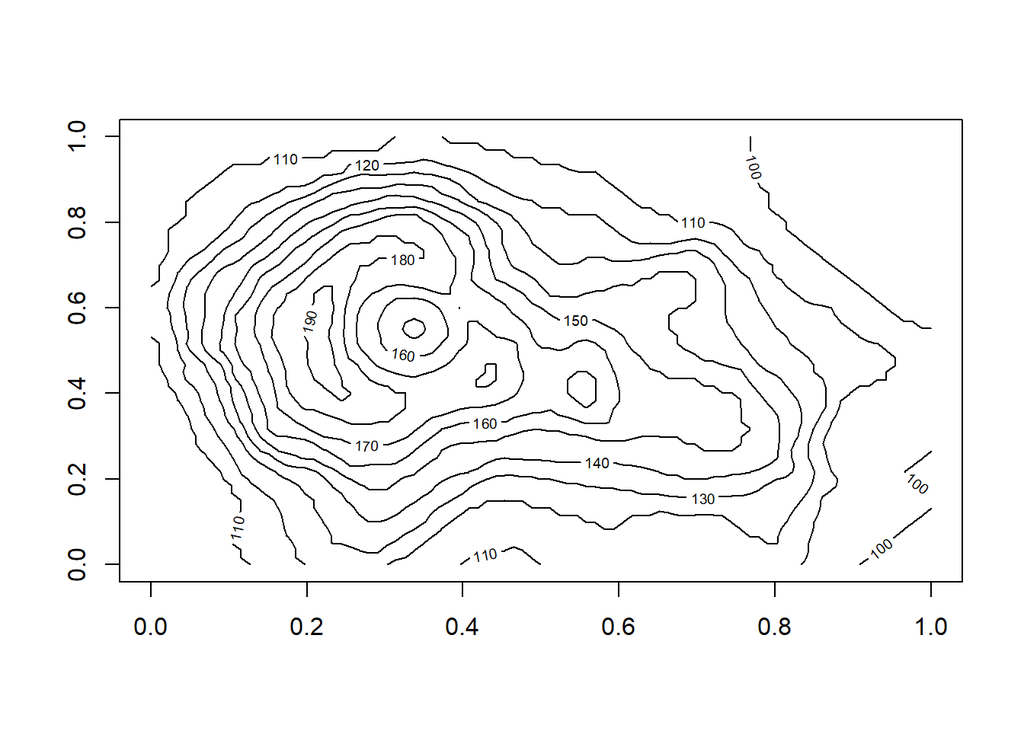

```r
contour(volcano)
```

perspective surface plot 3D, continuous, many observations, ordered grid, relationship

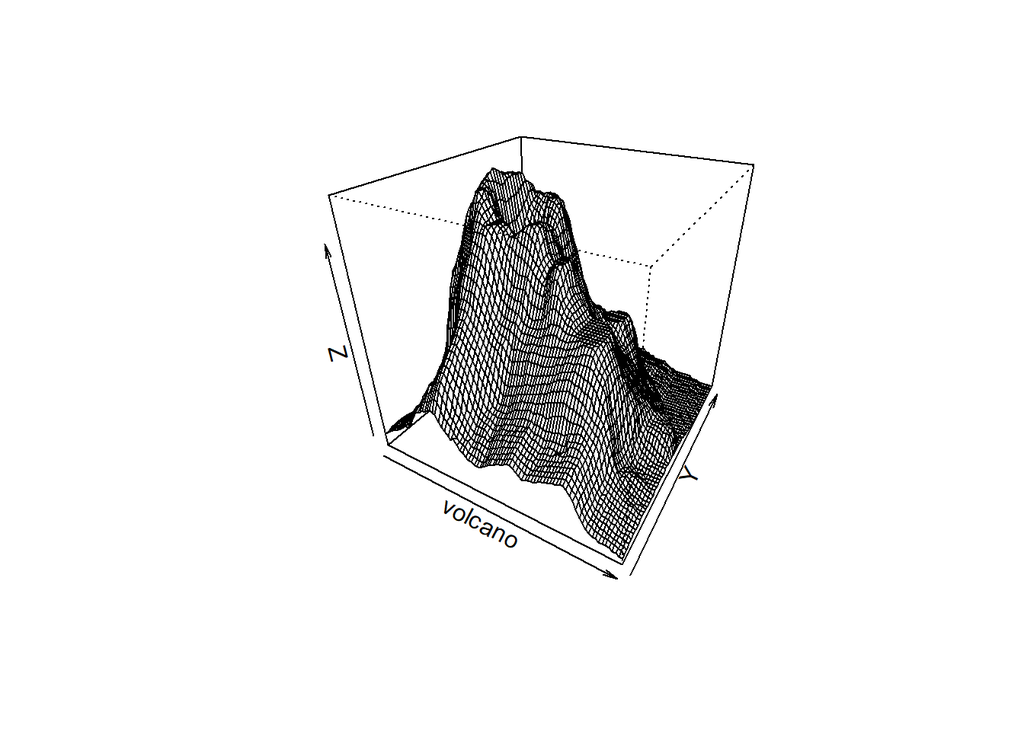

```r
persp(volcano, theta = 30, phi = 30)#Plots the volcano elevation data as a 3D wireframe surface viewed from a rotation angle of 30° and an elevation angle of 30°.
```

# Multidimensional Plotting

scatterplot matrix multidimensional, unordered, continuous, many observations, relationship

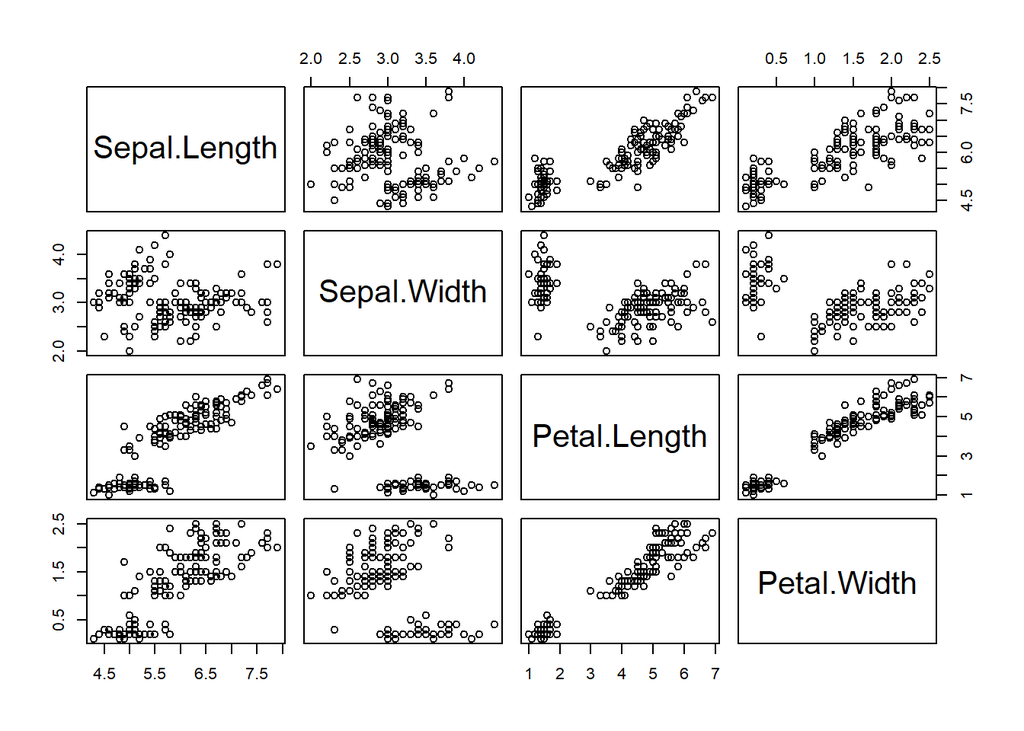

```r
pairs(iris[, 1:4])#Plots a grid of scatter plots showing every pairwise combination of the four numeric iris measurements (sepal length, sepal width, petal length, petal width).
```

conditioning plot multi dimensional, continuous, orderd conditioning

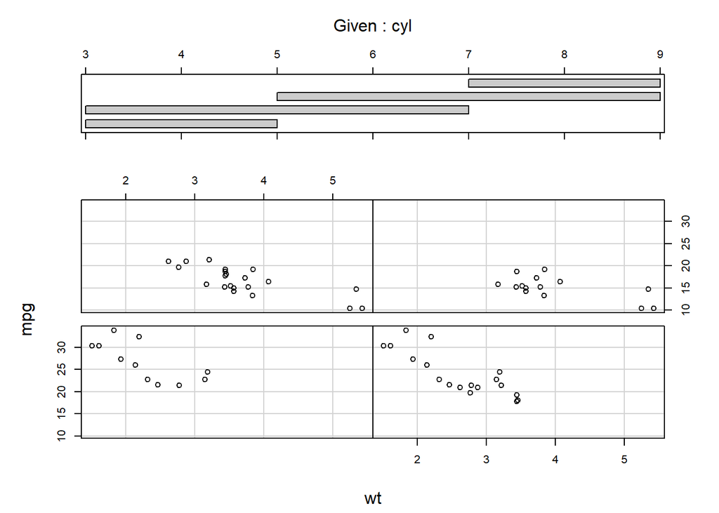

```r
coplot(mpg ~ wt | cyl, data = mtcars)#Plots mpg against weight as separate scatter panels, one for each cylinder group, to see if the weight-vs-mpg relationship differs by engine size.
```

mosaic plot for contingency tables multi dimensional, categorical, many observations, unordered, composition/relationship

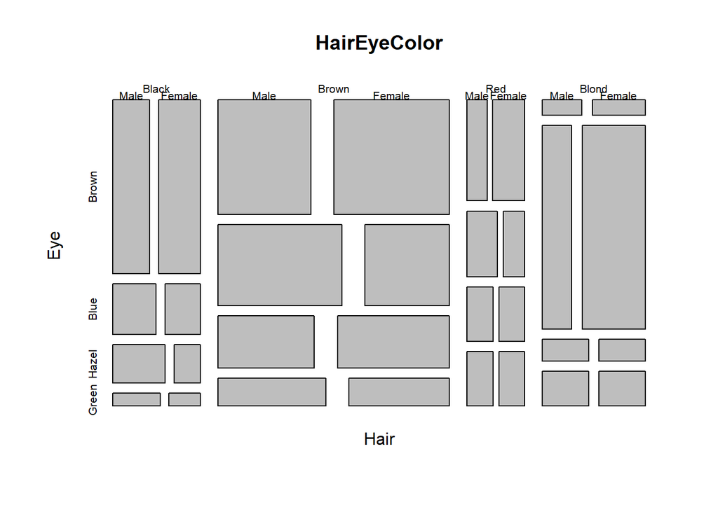

```r
mosaicplot(HairEyeColor)#Plots the joint distribution of hair color, eye color, and sex as nested rectangles whose areas are proportional to the cell frequencies in the contingency table.
```

# Task 1 b

We can write the labels for the x and y axis in the function. The key words are xlab and ylab.

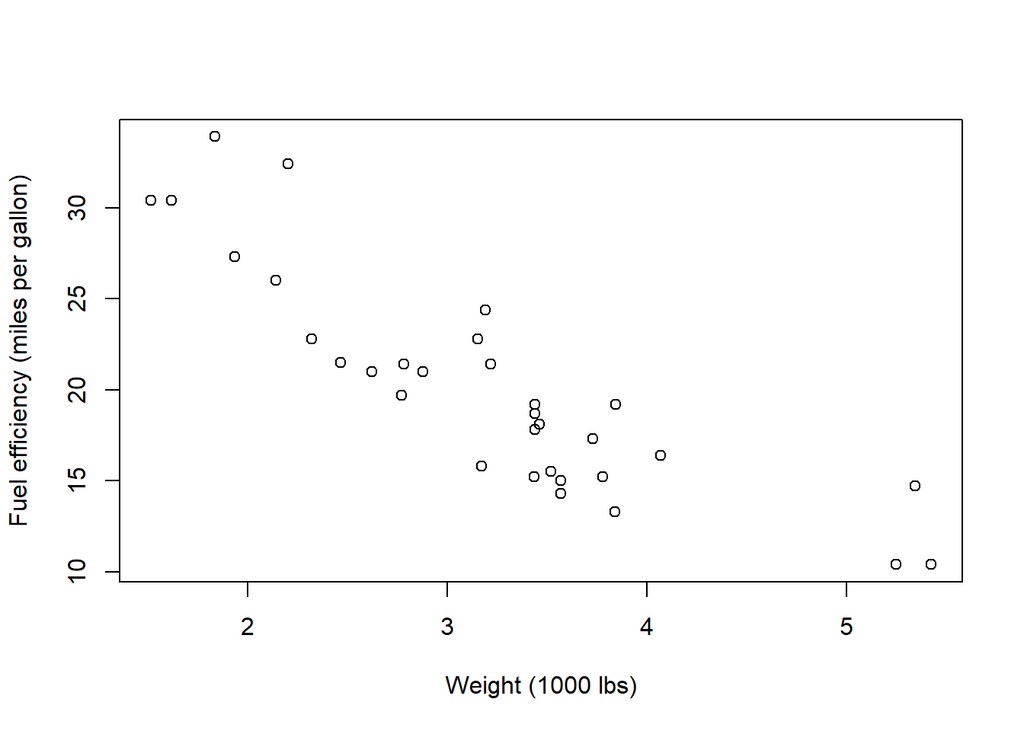

```r
plot(mtcars$wt, mtcars$mpg,
     xlab = "Weight (1000 lbs)",
     ylab = "Fuel efficiency (miles per gallon)")
```

We can use a log transformation by saying so in the function head:

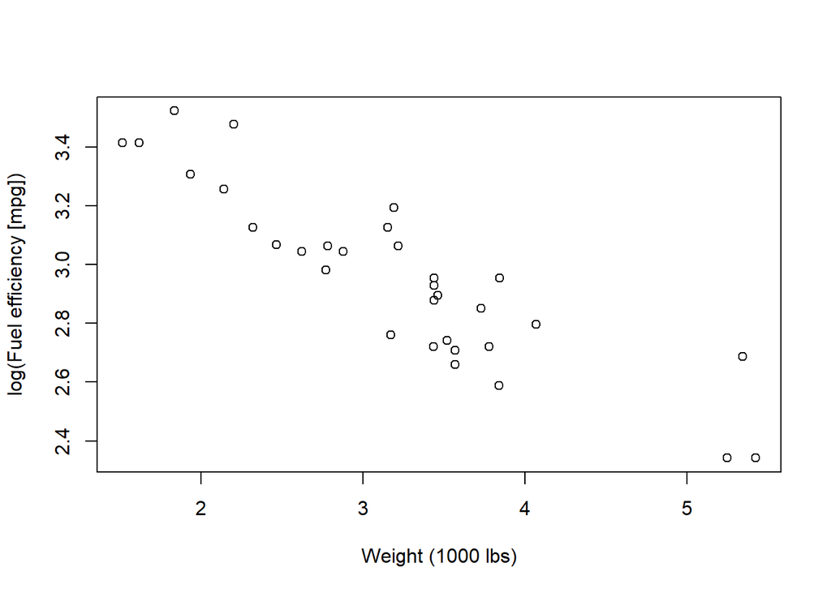

```r
plot(mtcars$wt, log(mtcars$mpg),
     xlab = "Weight (1000 lbs)",
     ylab = "log(Fuel efficiency [mpg])")
```

Or we tell the function which axis should get log transformed:

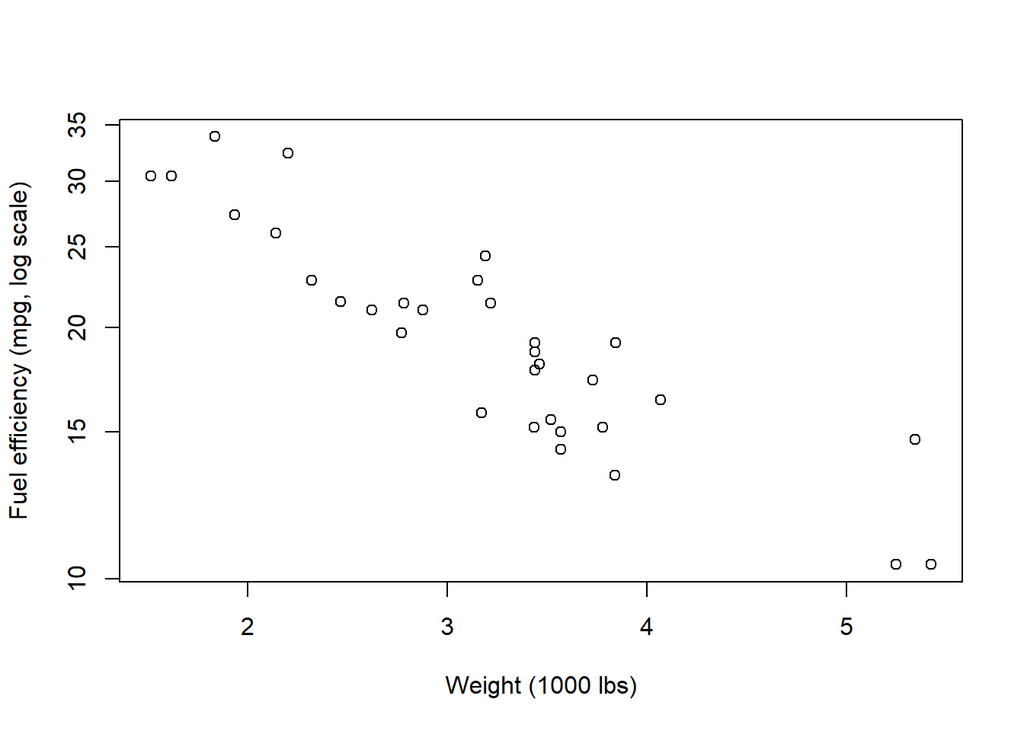

```r
plot(mtcars$wt, mtcars$mpg, log = "y",
     xlab = "Weight (1000 lbs)",
     ylab = "Fuel efficiency (mpg, log scale)")
```

cex (“character expansion”) scales text and points. 1 = default, 1.5 = 50 % larger, 0.8 = smaller.

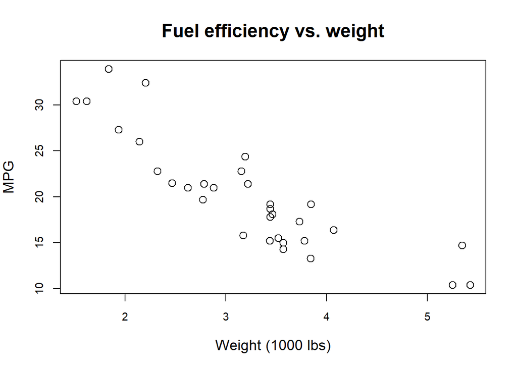

```r
plot(mtcars$wt, mtcars$mpg,
     main = "Fuel efficiency vs. weight",
     xlab = "Weight (1000 lbs)", ylab = "MPG",
     cex      = 1.3,   # point size
     cex.main = 1.5,   # title size
     cex.lab  = 1.2,   # axis label size
     cex.axis = 0.9)   # tick number size
```

# Task 2

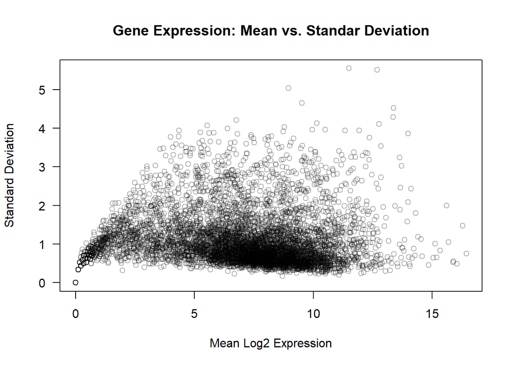

```r
raw_counts <- read.csv("basic_yeast_heatshock.csv", row.names = 1) # row.names = 1 moves 'gene_id' into the row labels position -> easy searching later on and no math Errors
log_counts <- log2(raw_counts + 1) # pseudocount for log-transformation

# Mean and standard deviation over all 9 replicates
genes_mean <- rowMeans(log_counts)
genes_sds <- apply(log_counts, 1, sd)

plot(genes_mean, genes_sds, main = "Gene Expression: Mean vs. Standar Deviation", xlab = "Mean Log2 Expression", ylab = "Standard Deviation", col = rgb(0,0,0,0.3), las = 1)
```

The scatter plot maps the global relationship between the average expression level of each gene and its standard deviation (variability) across all samples of the yeast heatshock experiment. The data reveals a high variability at an intermediate expression level, stabalizing at low and high Expression levels. the outlying points represent volatile genes with exceptionally high standard deviation, which undergo a condition specific regulatory shift. The graphic shows thas the log-transformation worked across the entire dataset.

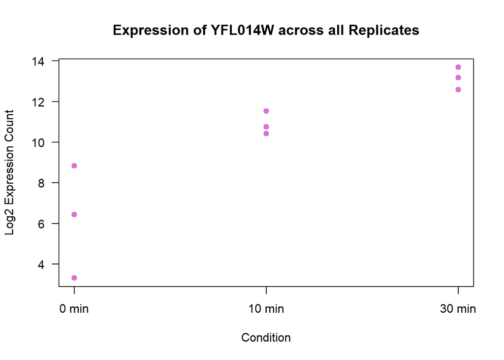

```r
yfl_data <- as.numeric(log_counts["YFL014W", ])
x_positions <- c(1, 1, 1, 2, 2, 2, 3, 3, 3) # assign positions to the replicates
plot(x_positions, yfl_data, main = "Expression of YFL014W across all Replicates", xlab = "Condition", ylab = "Log2 Expression Count", col = "orchid", pch = 19, xaxt = "n", las = 1)
axis(1, at = c(1, 2, 3), labels = c("0 min", "10 min", "30 min")) # adding condition labels and positions
```

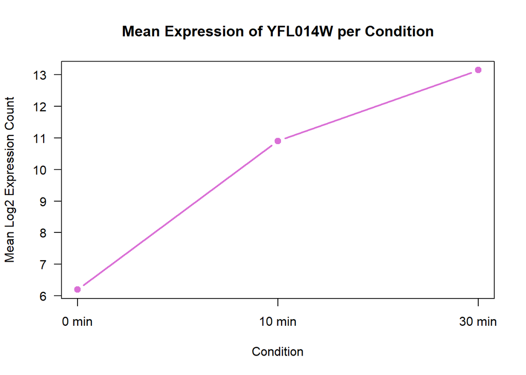

```r
yfl_mean_0min <- mean(yfl_data[1:3])
yfl_mean_10min <- mean(yfl_data[4:6])
yfl_mean_30min <- mean(yfl_data[7:9])
yfl_means <- c(yfl_mean_0min, yfl_mean_10min, yfl_mean_30min)

plot(c(1, 2, 3), yfl_means, type = "b", main = "Mean Expression of YFL014W per Condition", xlab = "Condition", ylab = "Mean Log2 Expression Count", col = "orchid", pch = 19, lwd = 2, xaxt = "n", las = 1)
axis(1, at = c(1, 2, 3), labels = c("0 min", "10 min", "30 min"))
```

By plotting the condition averages of this gene, this line plot puts the raw replicate data into a clean directional trajectory. The upward slope of the connecting line demonstrates a increase in mean log2 expression over the heat shock experiment. This visual representation focuses the attention on the overall trend rather than between sample variance, making it immediately that YFL014W ist strongly upregulated in response to thermal stress.

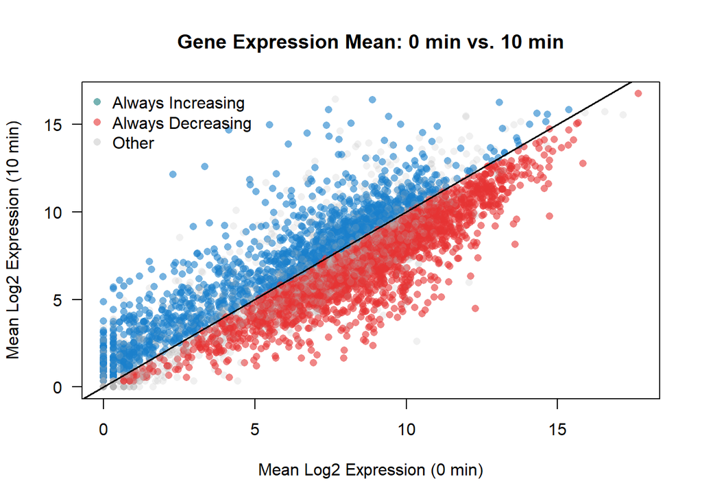

```r
# Calculate the mean Expression for every gene
mean_0min <- rowMeans(log_counts[, 1:3])
mean_10min <- rowMeans(log_counts[, 4:6])
mean_30min <- rowMeans(log_counts[, 7:9])

# Identify the genes always increasing or decreasing
always_increasing <- (mean_0min < mean_10min) & (mean_10min < mean_30min)
always_decreasing <- (mean_0min > mean_10min) & (mean_10min > mean_30min)

# Create a list of the gene names
genes_always_increasing <- rownames(log_counts)[always_increasing]
genes_always_decreasing <- rownames(log_counts)[always_decreasing]

# Custom color vector for these genes
gene_colors <- rep(rgb(0.7, 0.7, 0.7, 0.2), nrow(log_counts))
gene_colors[always_increasing] <- rgb(0.1, 0.5, 0.8, 0.6)
gene_colors[always_decreasing] <- rgb(0.9, 0.2, 0.2, 0.6)


# Plot1: 0min vs. 10min
plot(mean_0min, mean_10min, main = "Gene Expression Mean: 0 min vs. 10 min", xlab = "Mean Log2 Expression (0 min)", ylab = "Mean Log2 Expression (10 min)", col = gene_colors, pch = 16, las = 1)
abline(a = 0, b = 1, col = "black", lwd = 1.5)
legend("topleft", legend = c("Always Increasing", "Always Decreasing", "Other"), col = c(rgb(0.1, 0.5, 0.5, 0.6), rgb(0.9, 0.2, 0.2, 0.6), rgb(0.7, 0.7, 0.7, 0.4)), pch = 16, bty = "n")
```

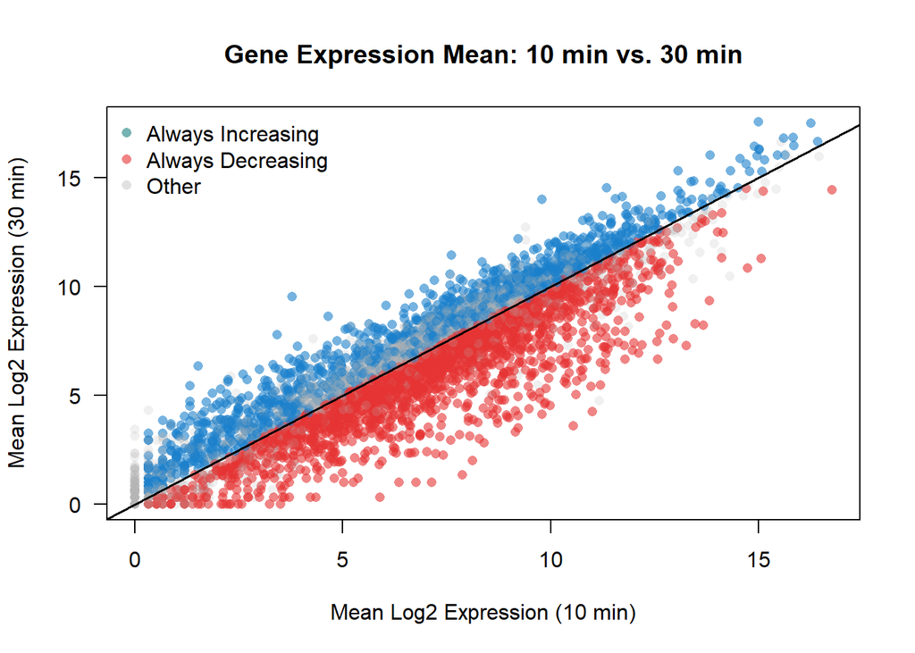

```r
#Plot2: 10 min vs. 30min
plot(mean_10min, mean_30min, main = "Gene Expression Mean: 10 min vs. 30 min", xlab = "Mean Log2 Expression (10 min)", ylab = "Mean Log2 Expression (30 min)", col = gene_colors, pch = 16, las = 1)
abline(a = 0, b = 1, col = "black", lwd = 1.5)
legend("topleft", legend = c("Always Increasing", "Always Decreasing", "Other"), col = c(rgb(0.1, 0.5, 0.5, 0.6), rgb(0.9, 0.2, 0.2, 0.6), rgb(0.7, 0.7, 0.7, 0.4)), pch = 16, bty = "n")
```

The second plot captures the subsequent transition of global gene expression between the 10-minute and 30-minute heat shock intervals. In contrast to the previous time step, the highlighted “Always Increasing” (blue) genes continue to maintain their position strictly above the diagonal line, proving that their expression continuously accumulates over the entire duration of the experiment. The “Always Decreasing” (red) genes remain below the diagonal, demonstrating an ongoing, progressive suppression. This visualization confirms that the identified gene subsets are not experiencing a temporary fluctuation, but are instead part of a sustained, coordinated transcriptional program to adapt to prolonged thermal stress.

# Task 3

```r
intron_data <- read.delim("data/AresLab_yeast_introns_2011.tsv", header = FALSE, stringsAsFactors = FALSE)
head(intron_data)
```

```
##                           V1      V2    V3     V4     V5
## 1 SNR17A_chr15_780120_780277  SNR17A chr15 780120 780277
## 2 SNR17B_chr16_281502_281372  SNR17B chr16 281502 281372
## 3 YAL001C_chr1_151097_151007 YAL001C  chr1 151097 151007
## 4 YAL003W_chr1_142255_142621 YAL003W  chr1 142255 142621
## 5   YAL030W_chr1_87389_87502 YAL030W  chr1  87389  87502
## 6 YBL018C_chr2_186389_186314 YBL018C  chr2 186389 186314
##                                                                                                                                                                                                                                                                                                          …
## 1                                                                                                                                                                                                                  GTATGTAATATACCCCAAACATTTTACCCACAAAAAACCAGGATTTGAAAACTATAGCATCTAAAAGTCTTAGGTACTAGAGTTTT…
## 2                                                                                                                                                                                                                                             GTATGTTTTATACCATATACTTTATTAGGAATATAACAAAGCATACCCAATAATTAGGC…
## 3                                                                                                                                                                                                                                                                                     GTATGTTCATGTCTCATTC…
## 4 GTATGTTCCGATTTAGTTTACTTTATAGATCGTTGTTTTTCTTTCTTTTTTTTTTTTCCT…
## 5                                                                                                                                                                                                                                                              GTAAGTACAGAAAGCCACAGAGTACCATCTAGGAAATTAACA…
## 6                                                                                                                                                                                                                                                                                                    GTAT…
```

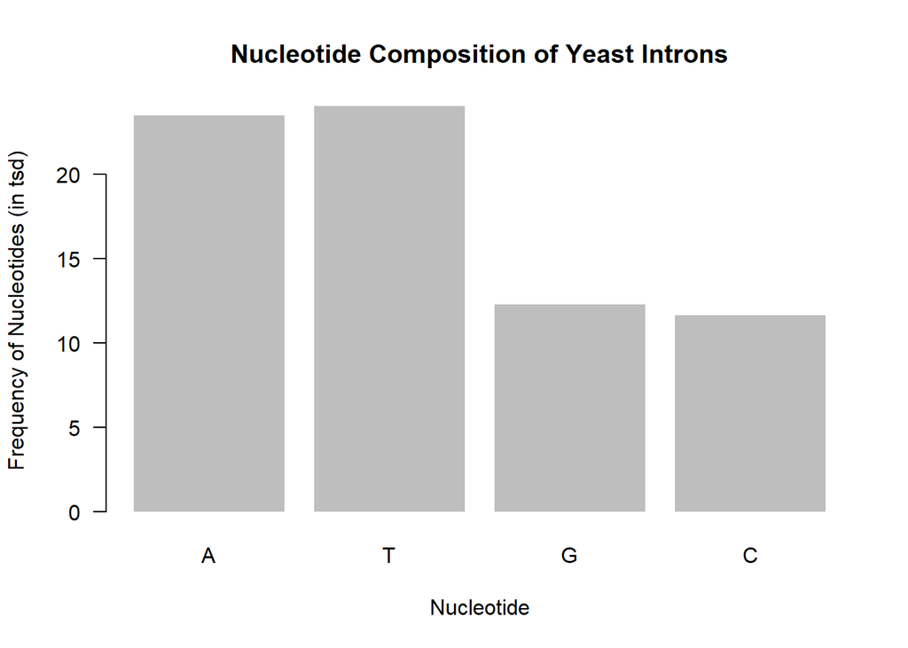

```r
all_sequences <- paste(toupper(intron_data$V6), collapse = "") # vector with all the bases in Uppercases
single_cases <- strsplit(all_sequences, "") [[1]]
base_counts <- table(single_cases) # counts everything and saves it
base_counts <- base_counts[c("A", "T", "G", "C")] # filter for the four bases

# Creating the barplot:
barplot(base_counts/ 1000, main = "Nucleotide Composition of Yeast Introns", xlab = "Nucleotide", ylab = "Frequency of Nucleotides (in tsd)", col = "grey", border = NA, las = 1, axes = TRUE)
```

The introns of Yeast consist of way more A-T bonds than G-C bonds (double amount). This reason could be more flexible bending and folding into the required shape for splicing, saving energy for the spliceosome.

```r
# Extracting the first an last bases (interesting for the spliceosome)
first_10 <- substr(intron_data$V6, start = 1, stop = 10)
lengths <- nchar(intron_data$V6)
last_10 <- substr(intron_data$V6, start = lengths - 9, stop = lengths)

# first Installing the Biopacker package
# install.packages("BiocManager")
# BiocManager::install(c("Biostrings", "seqLogo"))

library(Biostrings)
matrix_first_10 <- consensusMatrix(DNAStringSet(first_10)) # create a Matrix for the first 10 bases
matrix_last_10 <- consensusMatrix(DNAStringSet(last_10)) # create a Matrix for the last 10 bases

# filter unknown letters and gaps
pwm_first <- matrix_first_10[c("A", "C", "G", "T"), ]
pwm_last <- matrix_last_10[c("A", "C", "G", "T"), ]

library(seqLogo)
```

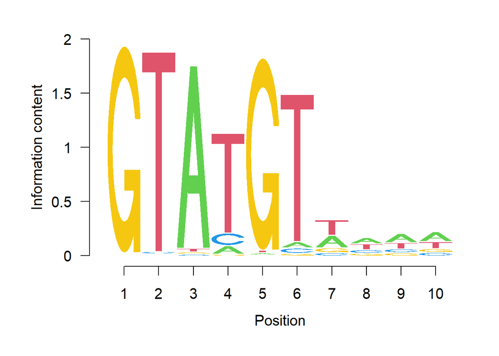

```r
# convert the raw count into proportions (margin = 2 > spply the calculation down each column)
pwm_first_prop <- prop.table(pwm_first, margin = 2)
pwm_last_prop  <- prop.table(pwm_last, margin = 2)

# turning frequencies into probabilities for Position Weight Matrix
pwm_first_final <- makePWM(pwm_first_prop)
pwm_last_final <- makePWM(pwm_last_prop)


# plot the seqLogo
seqLogo(pwm_first_final)
```

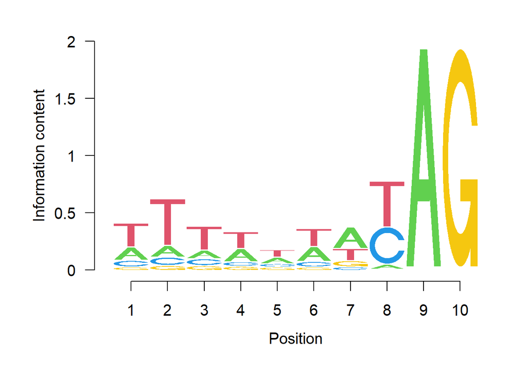

```r
seqLogo(pwm_last_final)
```

There is a highly conserved GTATGT motif at positions 1 to 6. The absolute height of G (position 1), T (position 2) and A (positon 3) indicates that almost every yeast intron begins with these two nucleotides, and may act as a recognition signal for the spliceosome to initiate splicing

The conserved mofit of A & G (two final positions before the next exon) represent the place where the splicing machine cuts of.

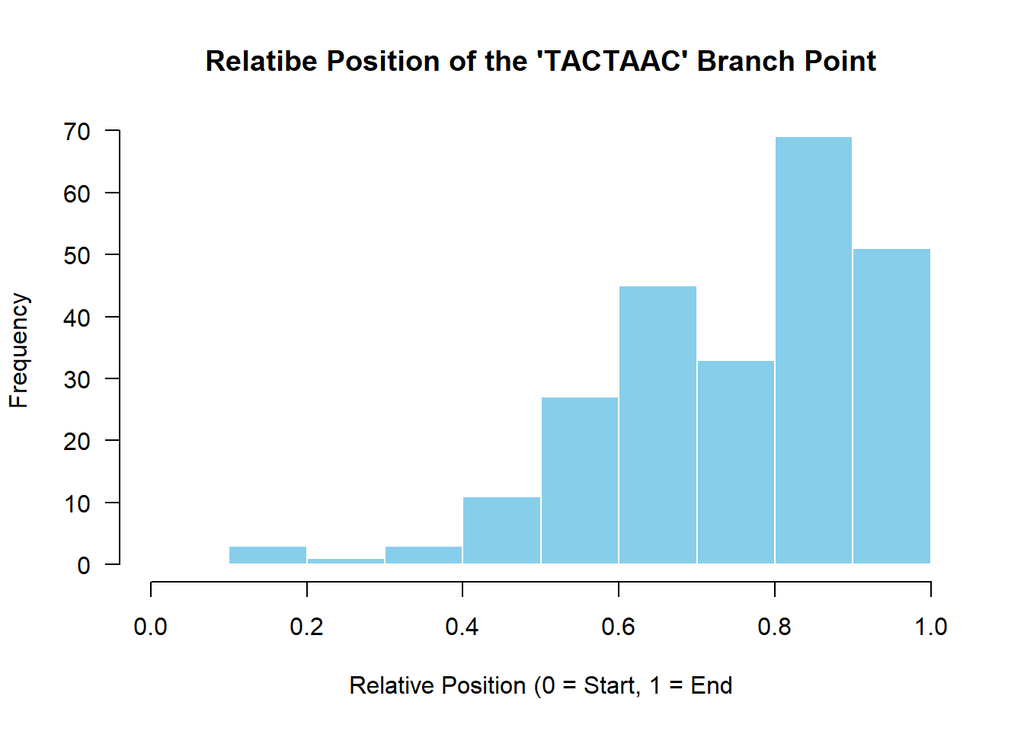

```r
# Find the starting position of 'TACTAAC' in every intron
bp_start <- regexpr("TACTAAC", intron_data$V6) # regexpr() tells the starting position of the search term (-1 if not found)
lengths <- nchar(intron_data$V6)
found_start <- which(bp_start != -1) # filter those rows with 'TACTAAC'
relative_positions <- bp_start[found_start] / lengths[found_start] # different intron lengths, relative position tells more about architecture of the intron
hist(relative_positions, main = "Relatibe Position of the 'TACTAAC' Branch Point", xlab = "Relative Position (0 = Start, 1 = End", ylab = "Frequency", col = "skyblue", border = "white", las = 1, xlim = c(0, 1))
```